# Results: Diskirminant.sas

The FREQ Procedure

| Saglik_Riski_Seviyesi | Saglik_Riski_Seviyesi Frequency | Saglik_Riski_Seviyesi Percent | Saglik_Riski_Seviyesi Cumulative Frequency | Saglik_Riski_Seviyesi Cumulative Percent |
| --- | --- | --- | --- | --- |
| 1 | 190 | 19.00 | 190 | 19.00 |
| 2 | 672 | 67.20 | 862 | 86.20 |
| 3 | 138 | 13.80 | 1000 | 100.00 |

The CORR Procedure

| 4 Variables: | Stress_Seviyesi_Biosensor Stress_Seviyesi_Bildirim Ders_Saatleri Proje_Saatleri |
| --- | --- |

| Simple Statistics Variable | Simple Statistics N | Simple Statistics Mean | Simple Statistics Std Dev | Simple Statistics Median | Simple Statistics Minimum | Simple Statistics Maximum | Simple Statistics Label |
| --- | --- | --- | --- | --- | --- | --- | --- |
| Stress_Seviyesi_Biosensor | 1000 | 5.48391 | 2.59611 | 5.36889 | 1.00849 | 9.99415 | Stress_Seviyesi_Biosensor |
| Stress_Seviyesi_Bildirim | 1000 | 5.36160 | 2.55038 | 5.23489 | 1.00219 | 9.96412 | Stress_Seviyesi_Bildirim |
| Ders_Saatleri | 1000 | 30.22704 | 10.34106 | 30.43277 | 5.00000 | 60.00000 | Ders_Saatleri |
| Proje_Saatleri | 1000 | 14.88737 | 4.88862 | 14.76587 | 0 | 32.72033 | Proje_Saatleri |

| Spearman Correlation Coefficients, N = 1000 Prob > \|r\| under H0: Rho=0 | Spearman Correlation Coefficients, N = 1000 Prob > \|r\| under H0: Rho=0 Stress_Seviyesi_Biosensor | Spearman Correlation Coefficients, N = 1000 Prob > \|r\| under H0: Rho=0 Stress_Seviyesi_Bildirim | Spearman Correlation Coefficients, N = 1000 Prob > \|r\| under H0: Rho=0 Ders_Saatleri | Spearman Correlation Coefficients, N = 1000 Prob > \|r\| under H0: Rho=0 Proje_Saatleri |
| --- | --- | --- | --- | --- |
| Stress_Seviyesi_Biosensor Stress_Seviyesi_Biosensor | 1.00000 | -0.02610 0.4096 | -0.03264 0.3024 | 0.00178 0.9550 |
| Stress_Seviyesi_Bildirim Stress_Seviyesi_Bildirim | -0.02610 0.4096 | 1.00000 | -0.00620 0.8447 | 0.01918 0.5445 |
| Ders_Saatleri Ders_Saatleri | -0.03264 0.3024 | -0.00620 0.8447 | 1.00000 | -0.04086 0.1967 |
| Proje_Saatleri Proje_Saatleri | 0.00178 0.9550 | 0.01918 0.5445 | -0.04086 0.1967 | 1.00000 |

The UNIVARIATE Procedure

Variable: Stress_Seviyesi_Biosensor (Stress_Seviyesi_Biosensor)

| Moments |  |  |  |
| --- | --- | --- | --- |
| N | 1000 | Sum Weights | 1000 |
| Mean | 5.48390941 | Sum Observations | 5483.90941 |
| Std Deviation | 2.59610848 | Variance | 6.73977925 |
| Skewness | 0.03704045 | Kurtosis | -1.1904309 |
| Uncorrected SS | 36806.3018 | Corrected SS | 6733.03947 |
| Coeff Variation | 47.3404699 | Std Error Mean | 0.08209616 |

| Basic Statistical Measures Location | Basic Statistical Measures Location | Basic Statistical Measures Variability | Basic Statistical Measures Variability |
| --- | --- | --- | --- |
| Mean | 5.483909 | Std Deviation | 2.59611 |
| Median | 5.368891 | Variance | 6.73978 |
| Mode | . | Range | 8.98566 |
|  |  | Interquartile Range | 4.40414 |

| Tests for Location: Mu0=0 Test | Tests for Location: Mu0=0 Statistic | Tests for Location: Mu0=0 Statistic | Tests for Location: Mu0=0 p Value | Tests for Location: Mu0=0 p Value |
| --- | --- | --- | --- | --- |
| Student's t | t | 66.79861 | Pr > \|t\| | <.0001 |
| Sign | M | 500 | Pr >= \|M\| | <.0001 |
| Signed Rank | S | 250250 | Pr >= \|S\| | <.0001 |

| Tests for Normality Test | Tests for Normality Statistic | Tests for Normality Statistic | Tests for Normality p Value | Tests for Normality p Value |
| --- | --- | --- | --- | --- |
| Shapiro-Wilk | W | 0.954674 | Pr < W | <0.0001 |
| Kolmogorov-Smirnov | D | 0.060409 | Pr > D | <0.0100 |
| Cramer-von Mises | W-Sq | 1.484052 | Pr > W-Sq | <0.0050 |
| Anderson-Darling | A-Sq | 10.91172 | Pr > A-Sq | <0.0050 |

| Quantiles (Definition 5) Level | Quantiles (Definition 5) Quantile |
| --- | --- |
| 100% Max | 9.99415 |
| 99% | 9.87300 |
| 95% | 9.64221 |
| 90% | 9.19057 |
| 75% Q3 | 7.67437 |
| 50% Median | 5.36889 |
| 25% Q1 | 3.27023 |
| 10% | 1.92409 |
| 5% | 1.48347 |
| 1% | 1.11790 |
| 0% Min | 1.00849 |

| Extreme Observations Lowest Value | Extreme Observations Lowest Obs | Extreme Observations Highest Value | Extreme Observations Highest Obs |
| --- | --- | --- | --- |
| 1.00849 | 106 | 9.95879 | 479 |
| 1.05442 | 28 | 9.96602 | 958 |
| 1.05565 | 467 | 9.97905 | 689 |
| 1.06618 | 363 | 9.98914 | 451 |
| 1.06717 | 990 | 9.99415 | 916 |

The UNIVARIATE Procedure

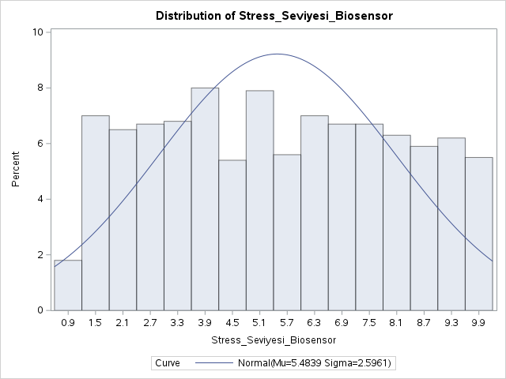

The UNIVARIATE Procedure

Fitted Normal Distribution for Stress_Seviyesi_Biosensor (Stress_Seviyesi_Biosensor)

| Parameters for Normal Distribution Parameter | Parameters for Normal Distribution Symbol | Parameters for Normal Distribution Estimate |
| --- | --- | --- |
| Mean | Mu | 5.483909 |
| Std Dev | Sigma | 2.596108 |

| Goodness-of-Fit Tests for Normal Distribution Test | Goodness-of-Fit Tests for Normal Distribution Statistic | Goodness-of-Fit Tests for Normal Distribution Statistic | Goodness-of-Fit Tests for Normal Distribution p Value | Goodness-of-Fit Tests for Normal Distribution p Value |
| --- | --- | --- | --- | --- |
| Kolmogorov-Smirnov | D | 0.0604087 | Pr > D | <0.010 |
| Cramer-von Mises | W-Sq | 1.4840525 | Pr > W-Sq | <0.005 |
| Anderson-Darling | A-Sq | 10.9117173 | Pr > A-Sq | <0.005 |

| Quantiles for Normal Distribution Percent | Quantiles for Normal Distribution Quantile Observed | Quantiles for Normal Distribution Quantile Estimated |
| --- | --- | --- |
| 1.0 | 1.11790 | -0.55554 |
| 5.0 | 1.48347 | 1.21369 |
| 10.0 | 1.92409 | 2.15686 |
| 25.0 | 3.27023 | 3.73286 |
| 50.0 | 5.36889 | 5.48391 |
| 75.0 | 7.67437 | 7.23496 |
| 90.0 | 9.19057 | 8.81096 |
| 95.0 | 9.64221 | 9.75413 |
| 99.0 | 9.87300 | 11.52336 |

The UNIVARIATE Procedure

Variable: Stress_Seviyesi_Bildirim (Stress_Seviyesi_Bildirim)

| Moments |  |  |  |
| --- | --- | --- | --- |
| N | 1000 | Sum Weights | 1000 |
| Mean | 5.36160057 | Sum Observations | 5361.60057 |
| Std Deviation | 2.55038224 | Variance | 6.50444955 |
| Skewness | 0.07184915 | Kurtosis | -1.1562091 |
| Uncorrected SS | 35244.7057 | Corrected SS | 6497.9451 |
| Coeff Variation | 47.5675538 | Std Error Mean | 0.08065017 |

| Basic Statistical Measures Location | Basic Statistical Measures Location | Basic Statistical Measures Variability | Basic Statistical Measures Variability |
| --- | --- | --- | --- |
| Mean | 5.361601 | Std Deviation | 2.55038 |
| Median | 5.234889 | Variance | 6.50445 |
| Mode | . | Range | 8.96193 |
|  |  | Interquartile Range | 4.30366 |

| Tests for Location: Mu0=0 Test | Tests for Location: Mu0=0 Statistic | Tests for Location: Mu0=0 Statistic | Tests for Location: Mu0=0 p Value | Tests for Location: Mu0=0 p Value |
| --- | --- | --- | --- | --- |
| Student's t | t | 66.47972 | Pr > \|t\| | <.0001 |
| Sign | M | 500 | Pr >= \|M\| | <.0001 |
| Signed Rank | S | 250250 | Pr >= \|S\| | <.0001 |

| Tests for Normality Test | Tests for Normality Statistic | Tests for Normality Statistic | Tests for Normality p Value | Tests for Normality p Value |
| --- | --- | --- | --- | --- |
| Shapiro-Wilk | W | 0.957983 | Pr < W | <0.0001 |
| Kolmogorov-Smirnov | D | 0.066909 | Pr > D | <0.0100 |
| Cramer-von Mises | W-Sq | 1.341929 | Pr > W-Sq | <0.0050 |
| Anderson-Darling | A-Sq | 10.03847 | Pr > A-Sq | <0.0050 |

| Quantiles (Definition 5) Level | Quantiles (Definition 5) Quantile |
| --- | --- |
| 100% Max | 9.96412 |
| 99% | 9.85830 |
| 95% | 9.48964 |
| 90% | 8.94342 |
| 75% Q3 | 7.47492 |
| 50% Median | 5.23489 |
| 25% Q1 | 3.17126 |
| 10% | 1.93144 |
| 5% | 1.44294 |
| 1% | 1.10618 |
| 0% Min | 1.00219 |

| Extreme Observations Lowest Value | Extreme Observations Lowest Obs | Extreme Observations Highest Value | Extreme Observations Highest Obs |
| --- | --- | --- | --- |
| 1.00219 | 253 | 9.93847 | 740 |
| 1.00369 | 634 | 9.94859 | 624 |
| 1.02113 | 42 | 9.96044 | 592 |
| 1.02719 | 608 | 9.96222 | 311 |
| 1.03348 | 534 | 9.96412 | 748 |

The UNIVARIATE Procedure

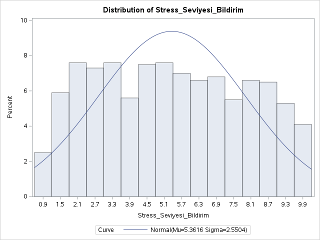

The UNIVARIATE Procedure

Fitted Normal Distribution for Stress_Seviyesi_Bildirim (Stress_Seviyesi_Bildirim)

| Parameters for Normal Distribution Parameter | Parameters for Normal Distribution Symbol | Parameters for Normal Distribution Estimate |
| --- | --- | --- |
| Mean | Mu | 5.361601 |
| Std Dev | Sigma | 2.550382 |

| Goodness-of-Fit Tests for Normal Distribution Test | Goodness-of-Fit Tests for Normal Distribution Statistic | Goodness-of-Fit Tests for Normal Distribution Statistic | Goodness-of-Fit Tests for Normal Distribution p Value | Goodness-of-Fit Tests for Normal Distribution p Value |
| --- | --- | --- | --- | --- |
| Kolmogorov-Smirnov | D | 0.0669094 | Pr > D | <0.010 |
| Cramer-von Mises | W-Sq | 1.3419290 | Pr > W-Sq | <0.005 |
| Anderson-Darling | A-Sq | 10.0384720 | Pr > A-Sq | <0.005 |

| Quantiles for Normal Distribution Percent | Quantiles for Normal Distribution Quantile Observed | Quantiles for Normal Distribution Quantile Estimated |
| --- | --- | --- |
| 1.0 | 1.10618 | -0.57148 |
| 5.0 | 1.44294 | 1.16660 |
| 10.0 | 1.93144 | 2.09315 |
| 25.0 | 3.17126 | 3.64139 |
| 50.0 | 5.23489 | 5.36160 |
| 75.0 | 7.47492 | 7.08181 |
| 90.0 | 8.94342 | 8.63005 |
| 95.0 | 9.48964 | 9.55661 |
| 99.0 | 9.85830 | 11.29468 |

The UNIVARIATE Procedure

Variable: Ders_Saatleri (Ders_Saatleri)

| Moments |  |  |  |
| --- | --- | --- | --- |
| N | 1000 | Sum Weights | 1000 |
| Mean | 30.2270372 | Sum Observations | 30227.0372 |
| Std Deviation | 10.3410603 | Variance | 106.937529 |
| Skewness | 0.01977975 | Kurtosis | -0.1499534 |
| Uncorrected SS | 1020504.37 | Corrected SS | 106830.591 |
| Coeff Variation | 34.2112932 | Std Error Mean | 0.32701304 |

| Basic Statistical Measures Location | Basic Statistical Measures Location | Basic Statistical Measures Variability | Basic Statistical Measures Variability |
| --- | --- | --- | --- |
| Mean | 30.22704 | Std Deviation | 10.34106 |
| Median | 30.43277 | Variance | 106.93753 |
| Mode | 5.00000 | Range | 55.00000 |
|  |  | Interquartile Range | 13.99259 |

| Tests for Location: Mu0=0 Test | Tests for Location: Mu0=0 Statistic | Tests for Location: Mu0=0 Statistic | Tests for Location: Mu0=0 p Value | Tests for Location: Mu0=0 p Value |
| --- | --- | --- | --- | --- |
| Student's t | t | 92.43374 | Pr > \|t\| | <.0001 |
| Sign | M | 500 | Pr >= \|M\| | <.0001 |
| Signed Rank | S | 250250 | Pr >= \|S\| | <.0001 |

| Tests for Normality Test | Tests for Normality Statistic | Tests for Normality Statistic | Tests for Normality p Value | Tests for Normality p Value |
| --- | --- | --- | --- | --- |
| Shapiro-Wilk | W | 0.997502 | Pr < W | 0.1302 |
| Kolmogorov-Smirnov | D | 0.012652 | Pr > D | >0.1500 |
| Cramer-von Mises | W-Sq | 0.02015 | Pr > W-Sq | >0.2500 |
| Anderson-Darling | A-Sq | 0.20185 | Pr > A-Sq | >0.2500 |

| Quantiles (Definition 5) Level | Quantiles (Definition 5) Quantile |
| --- | --- |
| 100% Max | 60.00000 |
| 99% | 55.19302 |
| 95% | 47.57748 |
| 90% | 43.09427 |
| 75% Q3 | 37.25456 |
| 50% Median | 30.43277 |
| 25% Q1 | 23.26198 |
| 10% | 16.62897 |
| 5% | 12.63280 |
| 1% | 5.39664 |
| 0% Min | 5.00000 |

| Extreme Observations Lowest Value | Extreme Observations Lowest Obs | Extreme Observations Highest Value | Extreme Observations Highest Obs |
| --- | --- | --- | --- |
| 5 | 891 | 56.8051 | 357 |
| 5 | 730 | 57.1362 | 62 |
| 5 | 665 | 58.9166 | 838 |
| 5 | 429 | 59.8633 | 64 |
| 5 | 354 | 60.0000 | 444 |

The UNIVARIATE Procedure

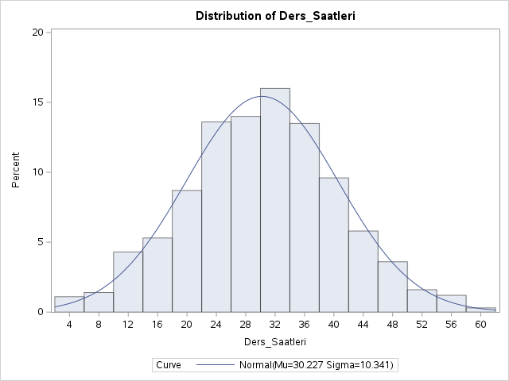

The UNIVARIATE Procedure

Fitted Normal Distribution for Ders_Saatleri (Ders_Saatleri)

| Parameters for Normal Distribution Parameter | Parameters for Normal Distribution Symbol | Parameters for Normal Distribution Estimate |
| --- | --- | --- |
| Mean | Mu | 30.22704 |
| Std Dev | Sigma | 10.34106 |

| Goodness-of-Fit Tests for Normal Distribution Test | Goodness-of-Fit Tests for Normal Distribution Statistic | Goodness-of-Fit Tests for Normal Distribution Statistic | Goodness-of-Fit Tests for Normal Distribution p Value | Goodness-of-Fit Tests for Normal Distribution p Value |
| --- | --- | --- | --- | --- |
| Kolmogorov-Smirnov | D | 0.01265207 | Pr > D | >0.150 |
| Cramer-von Mises | W-Sq | 0.02014994 | Pr > W-Sq | >0.250 |
| Anderson-Darling | A-Sq | 0.20184960 | Pr > A-Sq | >0.250 |

| Quantiles for Normal Distribution Percent | Quantiles for Normal Distribution Quantile Observed | Quantiles for Normal Distribution Quantile Estimated |
| --- | --- | --- |
| 1.0 | 5.39664 | 6.17013 |
| 5.0 | 12.63280 | 13.21751 |
| 10.0 | 16.62897 | 16.97444 |
| 25.0 | 23.26198 | 23.25210 |
| 50.0 | 30.43277 | 30.22704 |
| 75.0 | 37.25456 | 37.20198 |
| 90.0 | 43.09427 | 43.47964 |
| 95.0 | 47.57748 | 47.23657 |
| 99.0 | 55.19302 | 54.28394 |

The UNIVARIATE Procedure

Variable: Proje_Saatleri (Proje_Saatleri)

| Moments |  |  |  |
| --- | --- | --- | --- |
| N | 1000 | Sum Weights | 1000 |
| Mean | 14.8873684 | Sum Observations | 14887.3684 |
| Std Deviation | 4.88862352 | Variance | 23.8986399 |
| Skewness | 0.03659716 | Kurtosis | 0.14106853 |
| Uncorrected SS | 245508.479 | Corrected SS | 23874.7413 |
| Coeff Variation | 32.837392 | Std Error Mean | 0.15459185 |

| Basic Statistical Measures Location | Basic Statistical Measures Location | Basic Statistical Measures Variability | Basic Statistical Measures Variability |
| --- | --- | --- | --- |
| Mean | 14.88737 | Std Deviation | 4.88862 |
| Median | 14.76587 | Variance | 23.89864 |
| Mode | 0.00000 | Range | 32.72033 |
|  |  | Interquartile Range | 6.59782 |

| Tests for Location: Mu0=0 Test | Tests for Location: Mu0=0 Statistic | Tests for Location: Mu0=0 Statistic | Tests for Location: Mu0=0 p Value | Tests for Location: Mu0=0 p Value |
| --- | --- | --- | --- | --- |
| Student's t | t | 96.30112 | Pr > \|t\| | <.0001 |
| Sign | M | 499 | Pr >= \|M\| | <.0001 |
| Signed Rank | S | 249250.5 | Pr >= \|S\| | <.0001 |

| Tests for Normality Test | Tests for Normality Statistic | Tests for Normality Statistic | Tests for Normality p Value | Tests for Normality p Value |
| --- | --- | --- | --- | --- |
| Shapiro-Wilk | W | 0.998794 | Pr < W | 0.7507 |
| Kolmogorov-Smirnov | D | 0.020571 | Pr > D | >0.1500 |
| Cramer-von Mises | W-Sq | 0.039176 | Pr > W-Sq | >0.2500 |
| Anderson-Darling | A-Sq | 0.225611 | Pr > A-Sq | >0.2500 |

| Quantiles (Definition 5) Level | Quantiles (Definition 5) Quantile |
| --- | --- |
| 100% Max | 32.72033 |
| 99% | 26.52880 |
| 95% | 22.77416 |
| 90% | 21.10069 |
| 75% Q3 | 18.16325 |
| 50% Median | 14.76587 |
| 25% Q1 | 11.56543 |
| 10% | 8.54929 |
| 5% | 7.02213 |
| 1% | 2.73072 |
| 0% Min | 0.00000 |

| Extreme Observations Lowest Value | Extreme Observations Lowest Obs | Extreme Observations Highest Value | Extreme Observations Highest Obs |
| --- | --- | --- | --- |
| 0.000000 | 933 | 28.4399 | 180 |
| 0.000000 | 105 | 28.6156 | 499 |
| 0.485363 | 806 | 28.8134 | 932 |
| 0.886825 | 210 | 30.7482 | 49 |
| 0.980921 | 289 | 32.7203 | 204 |

The UNIVARIATE Procedure

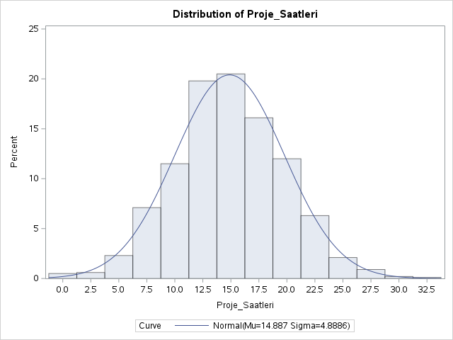

The UNIVARIATE Procedure

Fitted Normal Distribution for Proje_Saatleri (Proje_Saatleri)

| Parameters for Normal Distribution Parameter | Parameters for Normal Distribution Symbol | Parameters for Normal Distribution Estimate |
| --- | --- | --- |
| Mean | Mu | 14.88737 |
| Std Dev | Sigma | 4.888624 |

| Goodness-of-Fit Tests for Normal Distribution Test | Goodness-of-Fit Tests for Normal Distribution Statistic | Goodness-of-Fit Tests for Normal Distribution Statistic | Goodness-of-Fit Tests for Normal Distribution p Value | Goodness-of-Fit Tests for Normal Distribution p Value |
| --- | --- | --- | --- | --- |
| Kolmogorov-Smirnov | D | 0.02057117 | Pr > D | >0.150 |
| Cramer-von Mises | W-Sq | 0.03917590 | Pr > W-Sq | >0.250 |
| Anderson-Darling | A-Sq | 0.22561149 | Pr > A-Sq | >0.250 |

| Quantiles for Normal Distribution Percent | Quantiles for Normal Distribution Quantile Observed | Quantiles for Normal Distribution Quantile Estimated |
| --- | --- | --- |
| 1.0 | 2.73072 | 3.51473 |
| 5.0 | 7.02213 | 6.84630 |
| 10.0 | 8.54929 | 8.62235 |
| 25.0 | 11.56543 | 11.59004 |
| 50.0 | 14.76587 | 14.88737 |
| 75.0 | 18.16325 | 18.18469 |
| 90.0 | 21.10069 | 21.15239 |
| 95.0 | 22.77416 | 22.92844 |
| 99.0 | 26.52880 | 26.26001 |

The DISCRIM Procedure

| Total Sample Size | 1000 | DF Total | 999 |
| --- | --- | --- | --- |
| Variables | 4 | DF Within Classes | 997 |
| Classes | 3 | DF Between Classes | 2 |

| Number of Observations Read | 1000 |
| --- | --- |
| Number of Observations Used | 1000 |

| Class Level Information Saglik_Riski_Seviyesi | Class Level Information Variable Name | Class Level Information Frequency | Class Level Information Weight | Class Level Information Proportion | Class Level Information Prior Probability |
| --- | --- | --- | --- | --- | --- |
| 1 | 1 | 190 | 190.0000 | 0.190000 | 0.190000 |
| 2 | 2 | 672 | 672.0000 | 0.672000 | 0.672000 |
| 3 | 3 | 138 | 138.0000 | 0.138000 | 0.138000 |

The DISCRIM Procedure

Simple Statistics

| Total-Sample Variable | Total-Sample Label | Total-Sample N | Total-Sample Sum | Total-Sample Mean | Total-Sample Variance | Total-Sample Standard Deviation |
| --- | --- | --- | --- | --- | --- | --- |
| Stress_Seviyesi_Biosensor | Stress_Seviyesi_Biosensor | 1000 | 5484 | 5.48391 | 6.73978 | 2.5961 |
| Stress_Seviyesi_Bildirim | Stress_Seviyesi_Bildirim | 1000 | 5362 | 5.36160 | 6.50445 | 2.5504 |
| Ders_Saatleri | Ders_Saatleri | 1000 | 30227 | 30.22704 | 106.93753 | 10.3411 |
| Proje_Saatleri | Proje_Saatleri | 1000 | 14887 | 14.88737 | 23.89864 | 4.8886 |

| Saglik_Riski_Seviyesi = 1 Variable | Saglik_Riski_Seviyesi = 1 Label | Saglik_Riski_Seviyesi = 1 N | Saglik_Riski_Seviyesi = 1 Sum | Saglik_Riski_Seviyesi = 1 Mean | Saglik_Riski_Seviyesi = 1 Variance | Saglik_Riski_Seviyesi = 1 Standard Deviation |
| --- | --- | --- | --- | --- | --- | --- |
| Stress_Seviyesi_Biosensor | Stress_Seviyesi_Biosensor | 190 | 569.95442 | 2.99976 | 1.27734 | 1.1302 |
| Stress_Seviyesi_Bildirim | Stress_Seviyesi_Bildirim | 190 | 563.49413 | 2.96576 | 1.37498 | 1.1726 |
| Ders_Saatleri | Ders_Saatleri | 190 | 5786 | 30.45332 | 88.26753 | 9.3951 |
| Proje_Saatleri | Proje_Saatleri | 190 | 2773 | 14.59702 | 26.12162 | 5.1109 |

| Saglik_Riski_Seviyesi = 2 Variable | Saglik_Riski_Seviyesi = 2 Label | Saglik_Riski_Seviyesi = 2 N | Saglik_Riski_Seviyesi = 2 Sum | Saglik_Riski_Seviyesi = 2 Mean | Saglik_Riski_Seviyesi = 2 Variance | Saglik_Riski_Seviyesi = 2 Standard Deviation |
| --- | --- | --- | --- | --- | --- | --- |
| Stress_Seviyesi_Biosensor | Stress_Seviyesi_Biosensor | 672 | 3877 | 5.76957 | 6.05006 | 2.4597 |
| Stress_Seviyesi_Bildirim | Stress_Seviyesi_Bildirim | 672 | 3806 | 5.66314 | 5.65713 | 2.3785 |
| Ders_Saatleri | Ders_Saatleri | 672 | 20399 | 30.35511 | 111.84170 | 10.5755 |
| Proje_Saatleri | Proje_Saatleri | 672 | 10074 | 14.99049 | 23.44970 | 4.8425 |

| Saglik_Riski_Seviyesi = 3 Variable | Saglik_Riski_Seviyesi = 3 Label | Saglik_Riski_Seviyesi = 3 N | Saglik_Riski_Seviyesi = 3 Sum | Saglik_Riski_Seviyesi = 3 Mean | Saglik_Riski_Seviyesi = 3 Variance | Saglik_Riski_Seviyesi = 3 Standard Deviation |
| --- | --- | --- | --- | --- | --- | --- |
| Stress_Seviyesi_Biosensor | Stress_Seviyesi_Biosensor | 138 | 1037 | 7.51309 | 4.64587 | 2.1554 |
| Stress_Seviyesi_Bildirim | Stress_Seviyesi_Bildirim | 138 | 992.47537 | 7.19185 | 6.04489 | 2.4586 |
| Ders_Saatleri | Ders_Saatleri | 138 | 4042 | 29.29183 | 109.20292 | 10.4500 |
| Proje_Saatleri | Proje_Saatleri | 138 | 2040 | 14.78495 | 23.19998 | 4.8166 |

| Within Covariance Matrix Information Saglik_Riski_Seviyesi | Within Covariance Matrix Information Covariance Matrix Rank | Within Covariance Matrix Information Natural Log of the Determinant of the Covariance Matrix |
| --- | --- | --- |
| 1 | 4 | 8.29921 |
| 2 | 4 | 11.01827 |
| 3 | 4 | 10.90357 |
| Pooled | 4 | 10.87712 |

The DISCRIM Procedure

Test of Homogeneity of Within Covariance Matrices

| Chi-Square | DF | Pr > ChiSq |
| --- | --- | --- |
| 385.245755 | 20 | <.0001 |

Since the Chi-Square value is significant at the 0.1 level, the within covariance matrices will be used in the discriminant function.  
Reference: Morrison, D.F. (1976) Multivariate Statistical Methods p252.

The DISCRIM Procedure

| Generalized Squared Distance to Saglik_Riski_Seviyesi From Saglik_Riski_Seviyesi | Generalized Squared Distance to Saglik_Riski_Seviyesi 1 | Generalized Squared Distance to Saglik_Riski_Seviyesi 2 | Generalized Squared Distance to Saglik_Riski_Seviyesi 3 |
| --- | --- | --- | --- |
| 1 | 11.62067 | 17.65549 | 19.94064 |
| 2 | 23.37097 | 11.81326 | 15.59429 |
| 3 | 41.59724 | 13.92933 | 14.86457 |

The DISCRIM Procedure

Canonical Discriminant Analysis

|  | Canonical Correlation | Adjusted Canonical Correlation | Approximate Standard Error | Squared Canonical Correlation | Eigenvalues of Inv(E)*H = CanRsq/(1-CanRsq) Eigenvalue | Eigenvalues of Inv(E)*H = CanRsq/(1-CanRsq) Difference | Eigenvalues of Inv(E)*H = CanRsq/(1-CanRsq) Proportion | Eigenvalues of Inv(E)*H = CanRsq/(1-CanRsq) Cumulative | Test of H0: The canonical correlations in the current row and all that follow are zero Likelihood Ratio | Test of H0: The canonical correlations in the current row and all that follow are zero Approximate F Value | Test of H0: The canonical correlations in the current row and all that follow are zero Num DF | Test of H0: The canonical correlations in the current row and all that follow are zero Den DF | Test of H0: The canonical correlations in the current row and all that follow are zero Pr > F |
| --- | --- | --- | --- | --- | --- | --- | --- | --- | --- | --- | --- | --- | --- |
| 1 | 0.727055 | 0.725927 | 0.014914 | 0.528608 | 1.1214 | 1.1198 | 0.9986 | 0.9986 | 0.47065489 | 113.72 | 8 | 1988 | <.0001 |
| 2 | 0.039536 | 0.014311 | 0.031589 | 0.001563 | 0.0016 |  | 0.0014 | 1.0000 | 0.99843694 | 0.52 | 3 | 995 | 0.6691 |

The DISCRIM Procedure

Canonical Discriminant Analysis

| Total Canonical Structure Variable | Total Canonical Structure Label | Total Canonical Structure Can1 | Total Canonical Structure Can2 |
| --- | --- | --- | --- |
| Stress_Seviyesi_Biosensor | Stress_Seviyesi_Biosensor | 0.710166 | -0.228146 |
| Stress_Seviyesi_Bildirim | Stress_Seviyesi_Bildirim | 0.685356 | 0.240603 |
| Ders_Saatleri | Ders_Saatleri | -0.033528 | 0.683305 |
| Proje_Saatleri | Proje_Saatleri | 0.027529 | 0.634982 |

| Between Canonical Structure Variable | Between Canonical Structure Label | Between Canonical Structure Can1 | Between Canonical Structure Can2 |
| --- | --- | --- | --- |
| Stress_Seviyesi_Biosensor | Stress_Seviyesi_Biosensor | 0.999847 | -0.017467 |
| Stress_Seviyesi_Bildirim | Stress_Seviyesi_Bildirim | 0.999818 | 0.019087 |
| Ders_Saatleri | Ders_Saatleri | -0.669928 | 0.742426 |
| Proje_Saatleri | Proje_Saatleri | 0.623400 | 0.781903 |

| Pooled Within Canonical Structure Variable | Pooled Within Canonical Structure Label | Pooled Within Canonical Structure Can1 | Pooled Within Canonical Structure Can2 |
| --- | --- | --- | --- |
| Stress_Seviyesi_Biosensor | Stress_Seviyesi_Biosensor | 0.569381 | -0.266211 |
| Stress_Seviyesi_Bildirim | Stress_Seviyesi_Bildirim | 0.542762 | 0.277309 |
| Ders_Saatleri | Ders_Saatleri | -0.023035 | 0.683223 |
| Proje_Saatleri | Proje_Saatleri | 0.018911 | 0.634813 |

The DISCRIM Procedure

Canonical Discriminant Analysis

| Total-Sample Standardized Canonical Coefficients Variable | Total-Sample Standardized Canonical Coefficients Label | Total-Sample Standardized Canonical Coefficients Can1 | Total-Sample Standardized Canonical Coefficients Can2 |
| --- | --- | --- | --- |
| Stress_Seviyesi_Biosensor | Stress_Seviyesi_Biosensor | 1.059420831 | -0.206260836 |
| Stress_Seviyesi_Bildirim | Stress_Seviyesi_Bildirim | 1.024437680 | 0.221714180 |
| Ders_Saatleri | Ders_Saatleri | -0.012273942 | 0.704102321 |
| Proje_Saatleri | Proje_Saatleri | 0.005680394 | 0.658697517 |

| Pooled Within-Class Standardized Canonical Coefficients Variable | Pooled Within-Class Standardized Canonical Coefficients Label | Pooled Within-Class Standardized Canonical Coefficients Can1 | Pooled Within-Class Standardized Canonical Coefficients Can2 |
| --- | --- | --- | --- |
| Stress_Seviyesi_Biosensor | Stress_Seviyesi_Biosensor | 0.9081368353 | -.1768070412 |
| Stress_Seviyesi_Bildirim | Stress_Seviyesi_Bildirim | 0.8890344429 | 0.1924095005 |
| Ders_Saatleri | Ders_Saatleri | -.0122781106 | 0.7043414387 |
| Proje_Saatleri | Proje_Saatleri | 0.0056831572 | 0.6590179300 |

| Raw Canonical Coefficients Variable | Raw Canonical Coefficients Label | Raw Canonical Coefficients Can1 | Raw Canonical Coefficients Can2 |
| --- | --- | --- | --- |
| Stress_Seviyesi_Biosensor | Stress_Seviyesi_Biosensor | 0.4080803395 | -.0794500064 |
| Stress_Seviyesi_Bildirim | Stress_Seviyesi_Bildirim | 0.4016800562 | 0.0869337061 |
| Ders_Saatleri | Ders_Saatleri | -.0011869133 | 0.0680880199 |
| Proje_Saatleri | Proje_Saatleri | 0.0011619618 | 0.1347408968 |

| Class Means on Canonical Variables Saglik_Riski_Seviyesi | Class Means on Canonical Variables Can1 | Class Means on Canonical Variables Can2 |
| --- | --- | --- |
| 1 | -1.976700402 | -0.034628168 |
| 2 | 0.237662166 | 0.026133720 |
| 3 | 1.564232613 | -0.079583391 |

The DISCRIM Procedure

Classification Summary for Calibration Data: WORK.SAGLIK_DATA

Resubstitution Summary using Quadratic Discriminant Function

| Number of Observations and Percent Classified into Saglik_Riski_Seviyesi From Saglik_Riski_Seviyesi | Number of Observations and Percent Classified into Saglik_Riski_Seviyesi 1 | Number of Observations and Percent Classified into Saglik_Riski_Seviyesi 2 | Number of Observations and Percent Classified into Saglik_Riski_Seviyesi 3 | Number of Observations and Percent Classified into Saglik_Riski_Seviyesi Total |
| --- | --- | --- | --- | --- |
| 1 | 166 87.37 | 24 12.63 | 0 0.00 | 190 100.00 |
| 2 | 5 0.74 | 656 97.62 | 11 1.64 | 672 100.00 |
| 3 | 10 7.25 | 44 31.88 | 84 60.87 | 138 100.00 |
| Total | 181 18.10 | 724 72.40 | 95 9.50 | 1000 100.00 |
| Priors | 0.19 | 0.672 | 0.138 |  |

| Error Count Estimates for Saglik_Riski_Seviyesi | Error Count Estimates for Saglik_Riski_Seviyesi 1 | Error Count Estimates for Saglik_Riski_Seviyesi 2 | Error Count Estimates for Saglik_Riski_Seviyesi 3 | Error Count Estimates for Saglik_Riski_Seviyesi Total |
| --- | --- | --- | --- | --- |
| Rate | 0.1263 | 0.0238 | 0.3913 | 0.0940 |
| Priors | 0.1900 | 0.6720 | 0.1380 |  |

The STEPDISC Procedure

| The Method for Selecting Variables is STEPWISE |  |  |  |
| --- | --- | --- | --- |
| Total Sample Size | 1000 | Variable(s) in the Analysis | 4 |
| Class Levels | 3 | Variable(s) Will Be Included | 0 |
|  |  | Significance Level to Enter | 0.15 |
|  |  | Significance Level to Stay | 0.15 |

| Number of Observations Read | 1000 |
| --- | --- |
| Number of Observations Used | 1000 |

| Class Level Information Saglik_Riski_Seviyesi | Class Level Information Variable Name | Class Level Information Frequency | Class Level Information Weight | Class Level Information Proportion |
| --- | --- | --- | --- | --- |
| 1 | 1 | 190 | 190.0000 | 0.190000 |
| 2 | 2 | 672 | 672.0000 | 0.672000 |
| 3 | 3 | 138 | 138.0000 | 0.138000 |

The STEPDISC Procedure

Stepwise Selection: Step 1

| Statistics for Entry, DF = 2, 997 Variable | Statistics for Entry, DF = 2, 997 Label | Statistics for Entry, DF = 2, 997 R-Square | Statistics for Entry, DF = 2, 997 F Value | Statistics for Entry, DF = 2, 997 Pr > F | Statistics for Entry, DF = 2, 997 Tolerance |
| --- | --- | --- | --- | --- | --- |
| Stress_Seviyesi_Biosensor | Stress_Seviyesi_Biosensor | 0.2667 | 181.28 | <.0001 | 1.0000 |
| Stress_Seviyesi_Bildirim | Stress_Seviyesi_Bildirim | 0.2484 | 164.74 | <.0001 | 1.0000 |
| Ders_Saatleri | Ders_Saatleri | 0.0013 | 0.66 | 0.5166 | 1.0000 |
| Proje_Saatleri | Proje_Saatleri | 0.0010 | 0.51 | 0.5980 | 1.0000 |

| Variable Stress_Seviyesi_Biosensor will be entered. |
| --- |

| Variable(s) That Have Been Entered |
| --- |
| Stress_Seviyesi_Biosensor |

| Multivariate Statistics Statistic | Multivariate Statistics Value | Multivariate Statistics F Value | Multivariate Statistics Num DF | Multivariate Statistics Den DF | Multivariate Statistics Pr > F |
| --- | --- | --- | --- | --- | --- |
| Wilks' Lambda | 0.733323 | 181.28 | 2 | 997 | <.0001 |
| Pillai's Trace | 0.266677 | 181.28 | 2 | 997 | <.0001 |
| Average Squared Canonical Correlation | 0.133339 |  |  |  |  |

The STEPDISC Procedure

Stepwise Selection: Step 2

| Statistics for Removal, DF = 2, 997 Variable | Statistics for Removal, DF = 2, 997 Label | Statistics for Removal, DF = 2, 997 R-Square | Statistics for Removal, DF = 2, 997 F Value | Statistics for Removal, DF = 2, 997 Pr > F |
| --- | --- | --- | --- | --- |
| Stress_Seviyesi_Biosensor | Stress_Seviyesi_Biosensor | 0.2667 | 181.28 | <.0001 |

| No variables can be removed. |
| --- |

| Statistics for Entry, DF = 2, 996 Variable | Statistics for Entry, DF = 2, 996 Label | Statistics for Entry, DF = 2, 996 Partial R-Square | Statistics for Entry, DF = 2, 996 F Value | Statistics for Entry, DF = 2, 996 Pr > F | Statistics for Entry, DF = 2, 996 Tolerance |
| --- | --- | --- | --- | --- | --- |
| Stress_Seviyesi_Bildirim | Stress_Seviyesi_Bildirim | 0.3572 | 276.77 | <.0001 | 0.9993 |
| Ders_Saatleri | Ders_Saatleri | 0.0008 | 0.41 | 0.6619 | 0.9991 |
| Proje_Saatleri | Proje_Saatleri | 0.0010 | 0.49 | 0.6126 | 0.9999 |

| Variable Stress_Seviyesi_Bildirim will be entered. |
| --- |

| Variable(s) That Have Been Entered |  |
| --- | --- |
| Stress_Seviyesi_Biosensor | Stress_Seviyesi_Bildirim |

| Multivariate Statistics Statistic | Multivariate Statistics Value | Multivariate Statistics F Value | Multivariate Statistics Num DF | Multivariate Statistics Den DF | Multivariate Statistics Pr > F |
| --- | --- | --- | --- | --- | --- |
| Wilks' Lambda | 0.471360 | 227.36 | 4 | 1992 | <.0001 |
| Pillai's Trace | 0.528729 | 179.15 | 4 | 1994 | <.0001 |
| Average Squared Canonical Correlation | 0.264364 |  |  |  |  |

The STEPDISC Procedure

Stepwise Selection: Step 3

| Statistics for Removal, DF = 2, 996 Variable | Statistics for Removal, DF = 2, 996 Label | Statistics for Removal, DF = 2, 996 Partial R-Square | Statistics for Removal, DF = 2, 996 F Value | Statistics for Removal, DF = 2, 996 Pr > F |
| --- | --- | --- | --- | --- |
| Stress_Seviyesi_Biosensor | Stress_Seviyesi_Biosensor | 0.3729 | 296.10 | <.0001 |
| Stress_Seviyesi_Bildirim | Stress_Seviyesi_Bildirim | 0.3572 | 276.77 | <.0001 |

| No variables can be removed. |
| --- |

| Statistics for Entry, DF = 2, 995 Variable | Statistics for Entry, DF = 2, 995 Label | Statistics for Entry, DF = 2, 995 Partial R-Square | Statistics for Entry, DF = 2, 995 F Value | Statistics for Entry, DF = 2, 995 Pr > F | Statistics for Entry, DF = 2, 995 Tolerance |
| --- | --- | --- | --- | --- | --- |
| Ders_Saatleri | Ders_Saatleri | 0.0008 | 0.40 | 0.6711 | 0.9984 |
| Proje_Saatleri | Proje_Saatleri | 0.0006 | 0.32 | 0.7264 | 0.9987 |

| No variables can be entered. |
| --- |

| No further steps are possible. |
| --- |

The STEPDISC Procedure

| Stepwise Selection Summary Step | Stepwise Selection Summary Number In | Stepwise Selection Summary Entered | Stepwise Selection Summary Removed | Stepwise Selection Summary Label | Stepwise Selection Summary Partial R-Square | Stepwise Selection Summary F Value | Stepwise Selection Summary Pr > F | Stepwise Selection Summary Wilks' Lambda | Stepwise Selection Summary Pr < Lambda | Stepwise Selection Summary Average Squared Canonical Correlation | Stepwise Selection Summary Pr > ASCC |
| --- | --- | --- | --- | --- | --- | --- | --- | --- | --- | --- | --- |
| 1 | 1 | Stress_Seviyesi_Biosensor |  | Stress_Seviyesi_Biosensor | 0.2667 | 181.28 | <.0001 | 0.73332288 | <.0001 | 0.13333856 | <.0001 |
| 2 | 2 | Stress_Seviyesi_Bildirim |  | Stress_Seviyesi_Bildirim | 0.3572 | 276.77 | <.0001 | 0.47135972 | <.0001 | 0.26436441 | <.0001 |